# Predicting Passenger Survival

Richard Kublik

November 29, 2017

# Introduction

As an introductory data science project, I have chosen to explore the data provided by the [Titanic: Machine Learning from Disaster](https://www.kaggle.com/c/titanic) competition hosted by Kaggle. The competition is to build the best model that can predict whether a given passenger survived the sinking of the Titanic. As a first step, I performed [introductory data analysis](http://http://portfolio.richard.crkublik.com/Titanic/output/exploratory.html) to learn more about the passengers on board. In this second part, I will compare different machine learning algorithms and submit my solution to Kaggle.

# Data Munging

We begin by loading the required packages, and performing the data munging steps described in Part 1. For the current prediction task, we are given a training dataset, and a testing dataset. Both datasets have missing data, and we will combine them prior to performing the data munging steps detailed in part 1.

```r
# load the training dataset
train_data <- read_csv(file.path('..','data','train.csv'))
test_data <- read_csv(file.path('..','data','test.csv'))
# Preprocessing, data cleanup the same as for exploratory analysis
# initial pre-processing:
train_data <- train_data %>%
  mutate(Survived = factor(Survived, levels = c(1, 0), labels = c("yes", "no")))

titanic_data <- train_data %>%
  bind_rows(test_data) %>%
  mutate(Pclass = factor(Pclass),
         Sex = factor(Sex),
         Embarked = factor(Embarked),
         Title = factor(str_extract(Name, "[a-zA-z]+\\.")),
         FamilyName = str_extract(Name, "[a-zA-z]*"))
# Convert variable names to lowercase
names(titanic_data) <- tolower(names(titanic_data))

# Fill in missing values:

# CABIN
# find shared tickets:
ticket_deck <-  titanic_data %>%
  filter(!is.na(cabin)) %>%
  distinct(ticket, .keep_all = TRUE) %>%
  select(ticket, cabin) %>%
  mutate(deck = substr(cabin, 0, 1)) %>%
  select(-cabin)


# fill in missing deck from same ticket
titanic_data <- titanic_data %>%
  merge(ticket_deck, by = "ticket", all.x = TRUE) %>%
  mutate(tdeck = substr(cabin, 0, 1),
         deck = ifelse(!is.na(tdeck), tdeck, deck),
         deck = ifelse(is.na(deck), "U", deck)) %>%
  select(-tdeck)



# FARE
missing_fare <- titanic_data %>%
  filter(is.na(fare))
mean_fare <- titanic_data %>%
  filter(pclass == missing_fare$pclass,
         embarked == missing_fare$embarked,
         sex == missing_fare$sex) %>%
  summarize(mean_fare = mean(fare, na.rm = TRUE))
print(mean_fare)
```

```
##   mean_fare
## 1  13.14598
```

```r
titanic_data$fare[which(titanic_data$passengerid == missing_fare$passengerid)] <- mean_fare$mean_fare[1]

# EMBARKED
titanic_data$embarked[which(is.na(titanic_data$embarked))] <- "S"

# AGE
tb <- cbind(titanic_data$age, titanic_data$title)

# get the mean ages for each title
(age_dist <- titanic_data %>%
  group_by(title) %>%
  summarize(n = n(),
            n_missing = sum(is.na(age)),
            perc_missing = 100*n_missing/n,
            mean_age = mean(age, na.rm = TRUE),
            sd_age = sd(age, na.rm = TRUE),
            min_age = min(age, na.rm = TRUE),
            max_age = max(age, na.rm = TRUE)) %>%
  filter(n_missing > 0))
```

```
## # A tibble: 6 × 8
##     title     n n_missing perc_missing  mean_age    sd_age min_age max_age
##    <fctr> <int>     <int>        <dbl>     <dbl>     <dbl>   <dbl>   <dbl>
## 1     Dr.     8         1     12.50000 43.571429 11.731115   23.00    54.0
## 2 Master.    61         8     13.11475  5.482642  4.161554    0.33    14.5
## 3   Miss.   260        50     19.23077 21.774238 12.249077    0.17    63.0
## 4     Mr.   757       176     23.24967 32.252151 12.422089   11.00    80.0
## 5    Mrs.   197        27     13.70558 36.994118 12.901767   14.00    76.0
## 6     Ms.     2         1     50.00000 28.000000       NaN   28.00    28.0
```

```r
titanic_data <- titanic_data %>%
  mutate(age_est = 0)


bnorm <- function(nsamp, mean, std, lbound, ubound, rounding){
  samp <- round(rnorm(nsamp, mean, std), rounding)
  samp[samp < lbound] <- lbound
  samp[samp > ubound] <- ubound
  samp
}

for (key in c("Dr.", "Master.", "Miss.", "Mr.", "Mrs.")) {
  idx_na <- which(titanic_data$title == key & is.na(titanic_data$age))
  age_idx <- which(age_dist$title == key)
  titanic_data$age[idx_na] <- bnorm(length(idx_na),
                                    age_dist$mean_age[age_idx],
                                    age_dist$sd_age[age_idx],
                                    age_dist$min_age[age_idx],
                                    age_dist$max_age[age_idx],
                                    1)
  titanic_data$age_est[idx_na] <- 1
}
# impute single missing Ms. value to be the mean:
idx_na <- which(titanic_data$title == "Ms." & is.na(titanic_data$age))
age_idx <- which(age_dist$title == "Ms.")
titanic_data$age[idx_na] <- age_dist$mean_age[age_idx]
titanic_data$age_est[idx_na] <- 1
```

## Additional Feature Engineering

### Passenger Titles

We have already seen that there are many different titles assigned to the passengers:

| title | sex | Num_Passengers |
| --- | --- | --- |
| Capt. | male | 1 |
| Col. | male | 4 |
| Countess. | female | 1 |
| Don. | male | 1 |
| Dona. | female | 1 |
| Dr. | female | 1 |
| Dr. | male | 7 |
| Jonkheer. | male | 1 |
| Lady. | female | 1 |
| Major. | male | 2 |
| Master. | male | 61 |
| Miss. | female | 260 |
| Mlle. | female | 2 |
| Mme. | female | 1 |
| Mr. | male | 757 |
| Mrs. | female | 197 |
| Ms. | female | 2 |
| Rev. | male | 8 |
| Sir. | male | 1 |

While these titles were informative, they add a level of complexity that may have a detremental effect on the machine learning models that we will be looking at. We will reduce the number of titles to 4: Mr., Mrs., Master., and Miss. These titles capture both gender and age information.

```r
titanic_data <- titanic_data %>%
  mutate(title = as.character(title),
         title = ifelse((title == "Dr.") & sex == "female", "Mrs.", title),
         title = ifelse(title == "Mlle.", "Miss.", title),
         title = ifelse((title != "Miss.") & sex == "female", "Mrs.", title),
         title = ifelse((title != "Master.") & sex == "male", "Mr.", title),
         title = factor(title))
```

### Age Categories

While the passenger title can serve as a proxy for both gender and age (eg. Master refers to males under the age of 15), it is not very specific (eg. Miss refers to an unmarried woman of any age). We will create a new categorical variable for age with categories: child, teen, adult, senior.To get a sense of where the category splits should be, we look at the histogram of ages:

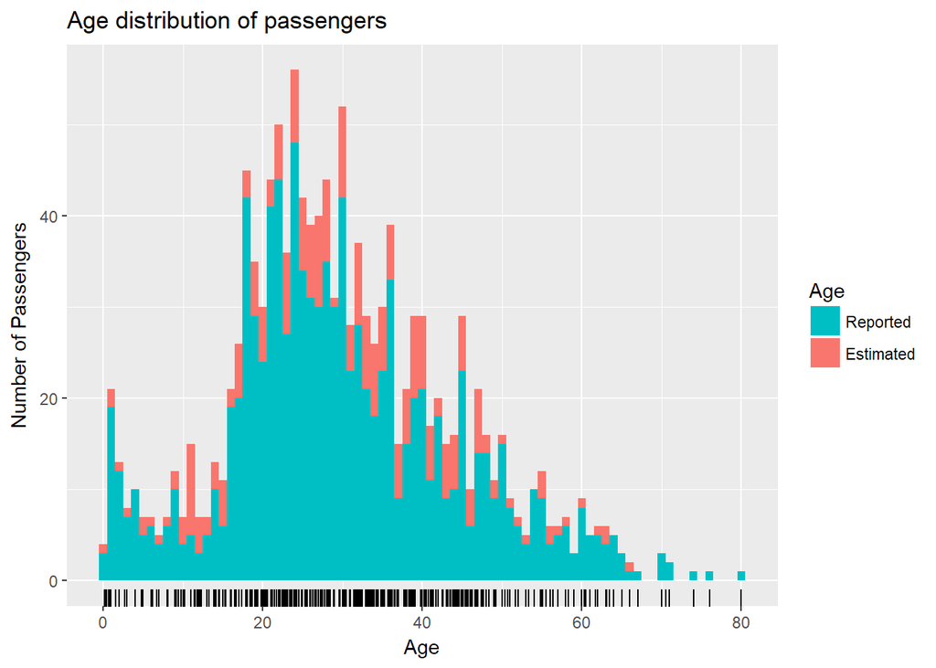

```r
titanic_data %>%
  ggplot(aes(x = age, fill = factor(age_est, levels = c(1, 0)))) +
  geom_histogram(binwidth = 1) +
  geom_rug() +
  ggtitle('Age distribution of passengers') +
  scale_fill_discrete(name = "Age",
                      breaks = c("0", "1"),
                      labels = c("Reported", "Estimated")) +
  labs(x = "Age",
       y = "Number of Passengers")
```

```r
titanic_data <- titanic_data %>%
    mutate(ageclass = ifelse(age < 10, 'child',
                           ifelse(age < 20, 'teen',
                                  ifelse(age < 60, 'adult', 'senior')
                                  )
                           )
         ) %>%
  mutate(ageclass = as.factor(ageclass))
```

### Family Size

There are 2 variables that get at how large families are: *parch*, and *sibsp*. We create a *familysize* variable to combine these values.

```r
titanic_data <- titanic_data %>%
  mutate(familysize = 1 + parch + sibsp)
```

### Remove unhelpful data

We remove variables that cannot be used for prediction

```r
titanic_data <- titanic_data %>%
  select(-ticket, -name, -cabin, -familyname, -age_est)
```

## Data Exploration

In this section we look at the relationships between each variable and passenger survival. We begin by noting that there is only 1 passenger with a deck value of “T”. For our models to be able to handle all cases, this passenger must be in the training set, and just adds noise into the model. We will remove it now. *** need to make sure all levels of each variable are in training dataset ***

```r
titanic_data <- titanic_data %>% filter(deck != "T")
```

Next, separate the data again into the training and testing datasets that were provided.

```r
# separate provided training/testing datasets
test_idx <- which(is.na(titanic_data$survived))
train_data <- titanic_data[-test_idx,]
test_data <-  titanic_data[test_idx,]
```

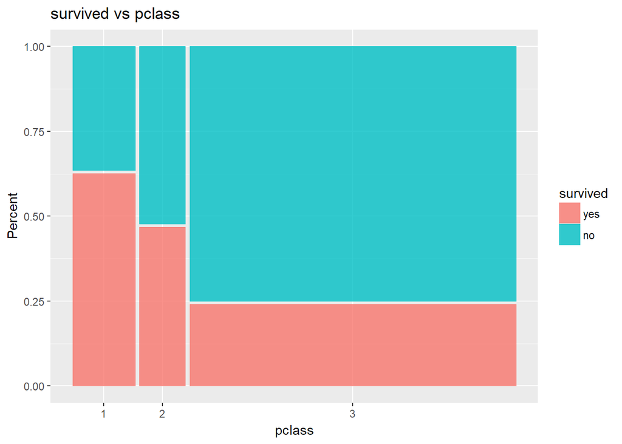

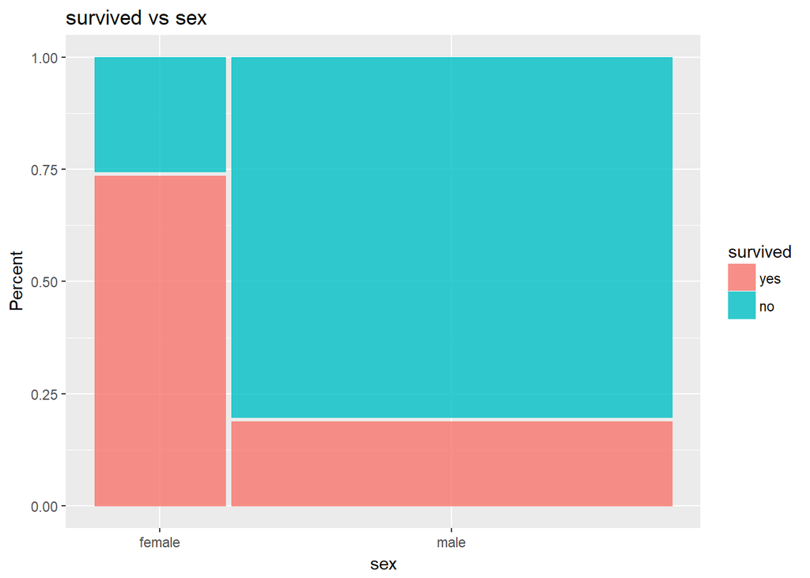

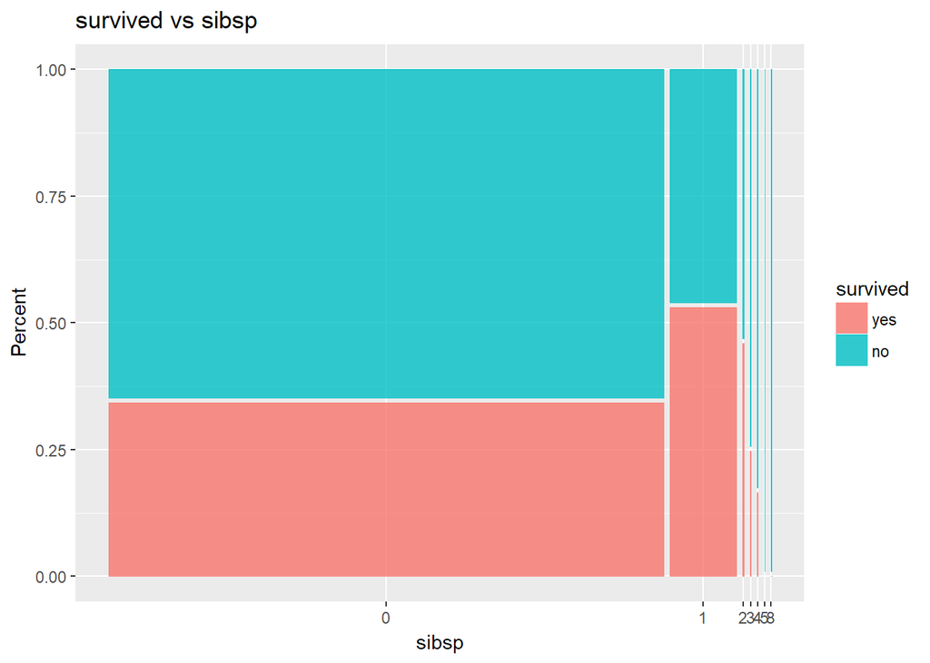

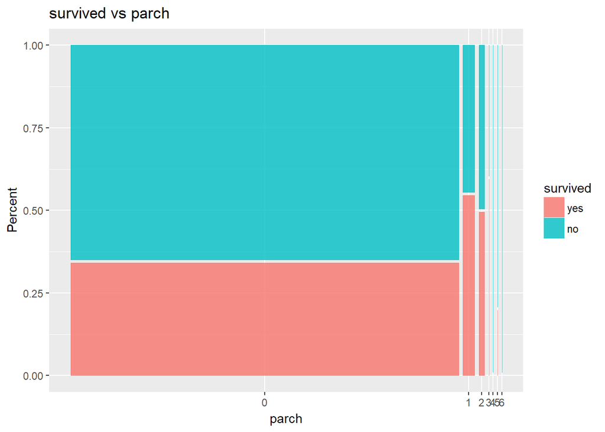

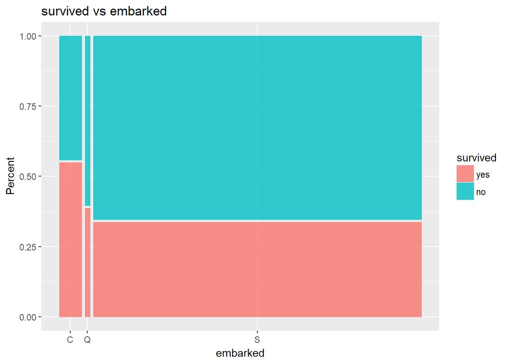

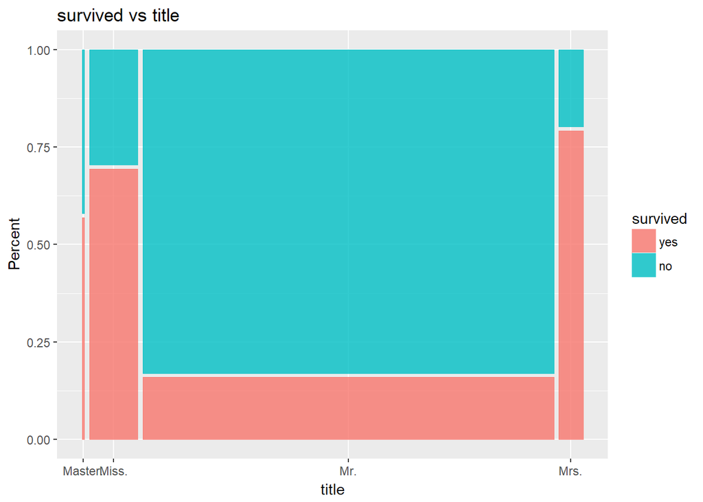

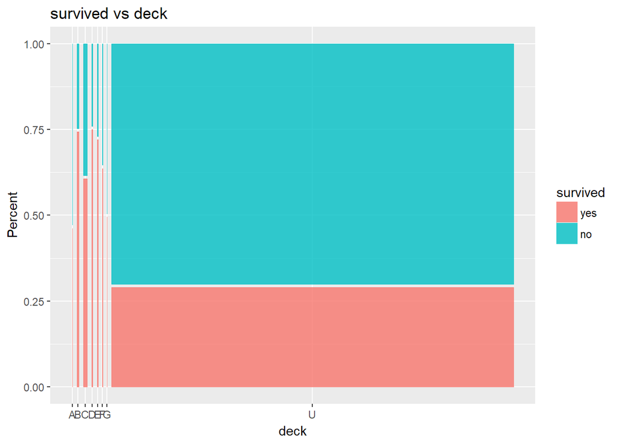

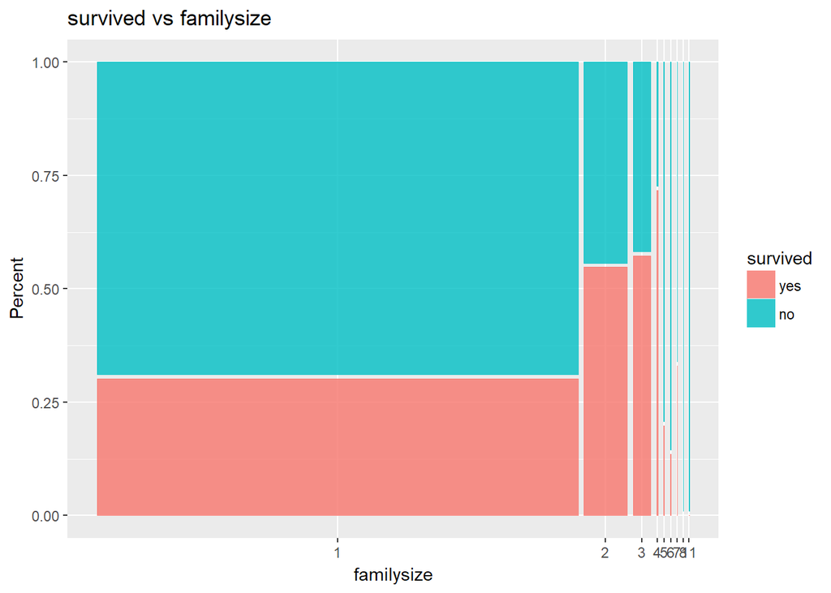

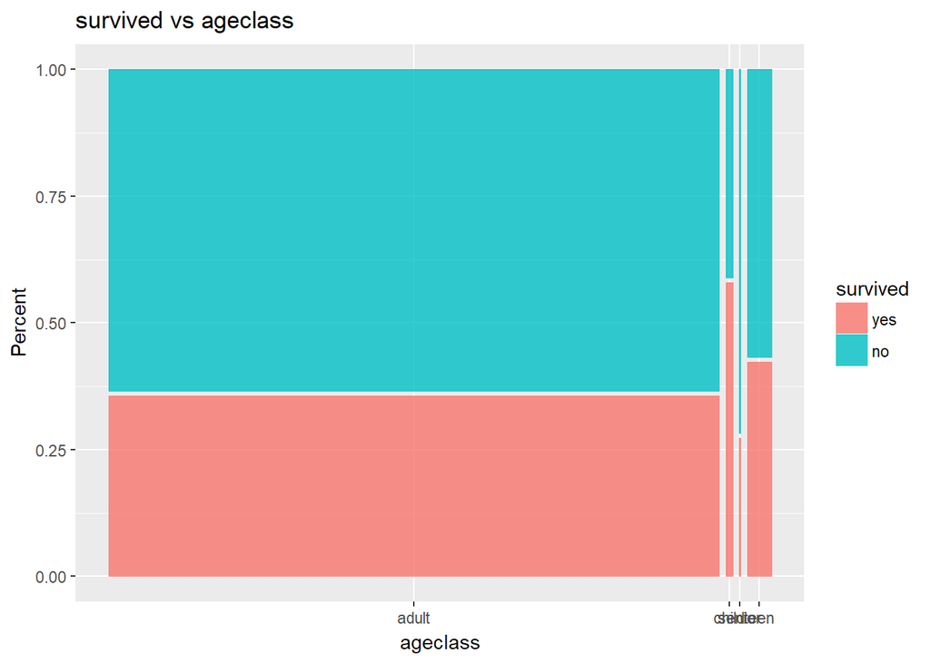

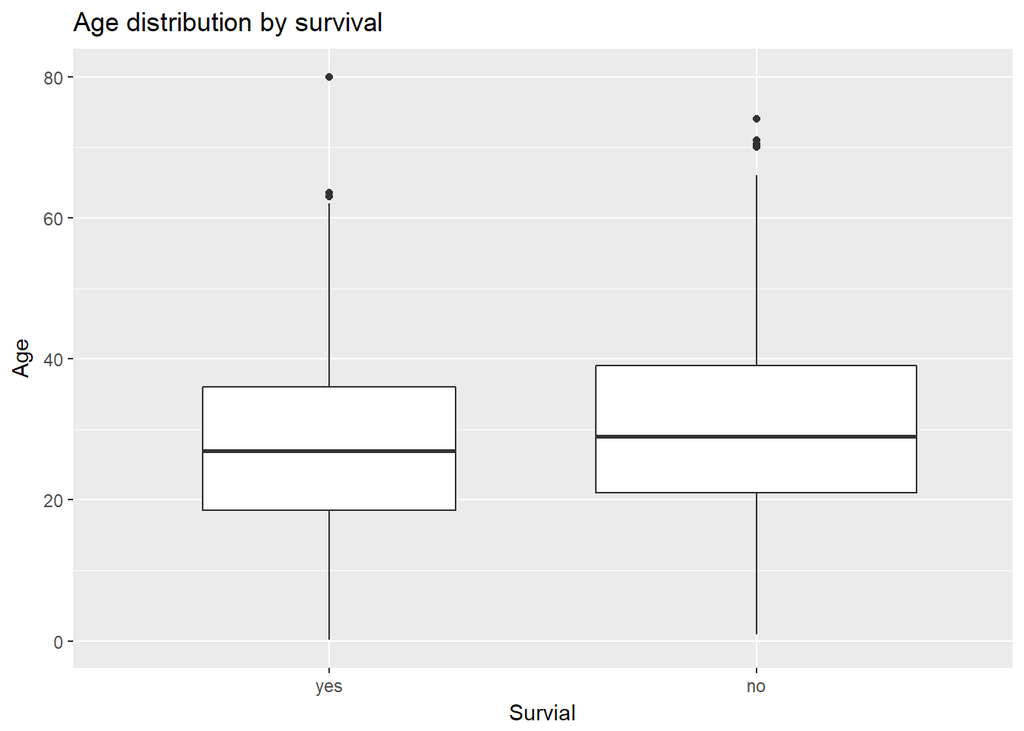

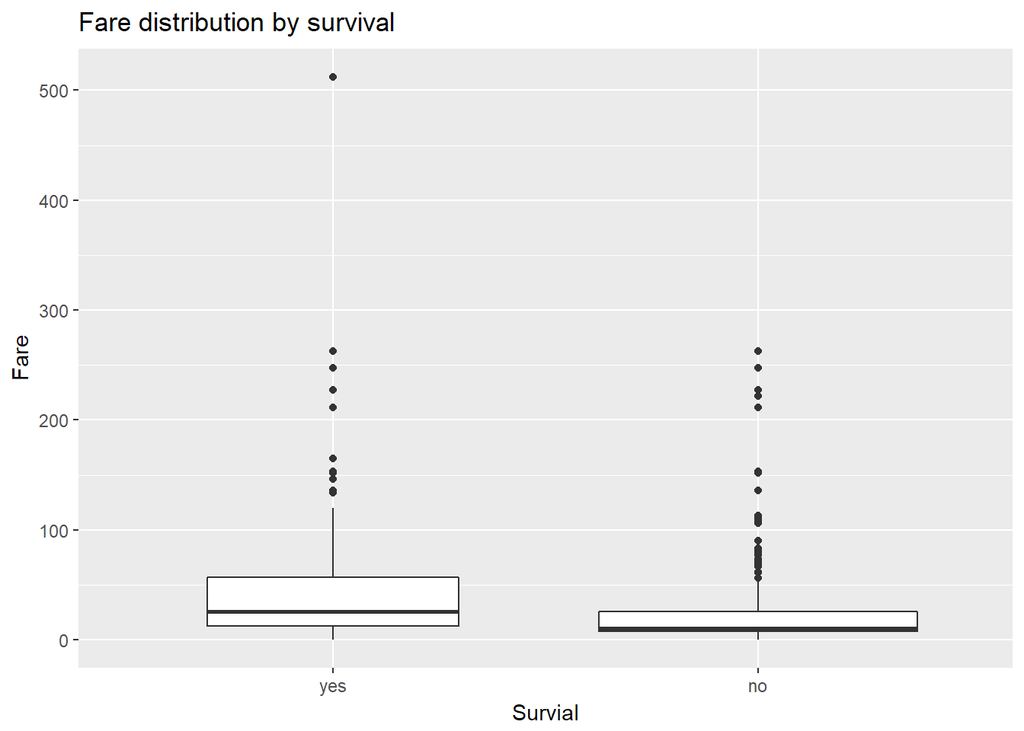

From these plots we see some trends that we would expect:

- First class passengers were most likely to survive, and third class passengers least likely to survive
- Women were more likely to survive than men
- Survival rates by age category show that the younger you are, the more likely to survive
- Passengers with title Mr. were much less likely to survive than other passengers

And one that we wouldn’t:

- Family size has an effect on survival, with survival rates increasing upto family size of 4, then decreasing dramatically

## PCA:

In many cases, Principal Component Analysis (PCA) can provide some insight into the data. By plotting the data in PCA space we can potentially see clustering in the data, along with information about co-linearity of the variables. Plotting the PCA of the input variables, we obtain:

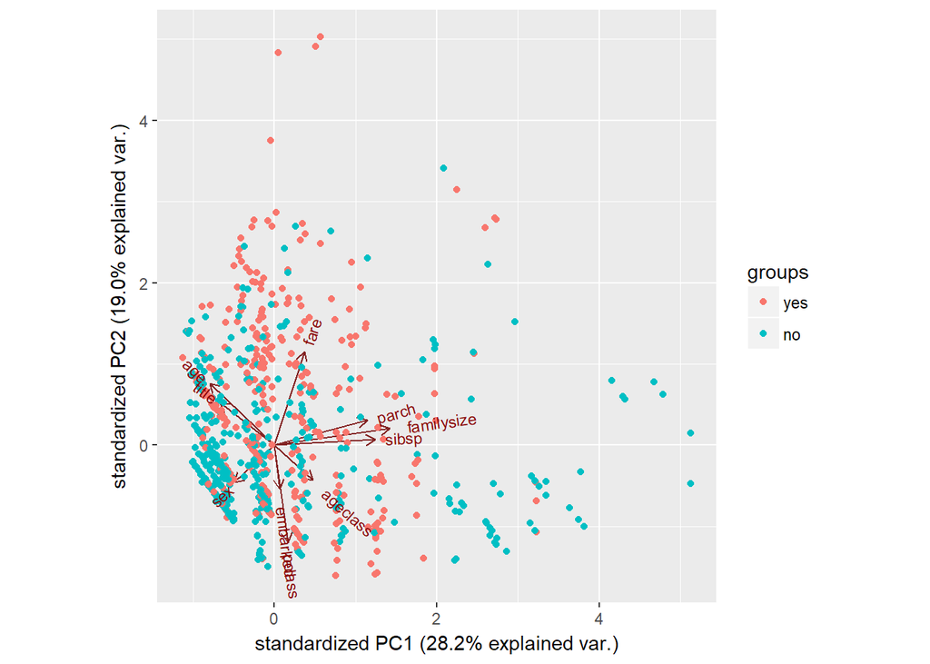

```r
train_pca <- train_data %>%
  select(-survived, -passengerid, -deck) %>%
  # convert factors to numeric values
  mutate(#survived = as.numeric(survived),
         pclass = as.numeric(pclass),
         sex = as.numeric(sex),
         age = as.numeric(age),
         sibsp = as.numeric(sibsp),
         parch = as.numeric(parch),
         fare = as.numeric(fare),
         embarked = as.numeric(embarked),
         title = as.numeric(title),
         ageclass = as.numeric(ageclass),
         familysize = as.numeric(familysize)) %>%
  # Calculate PCA
  prcomp(center = TRUE, scale = TRUE)

ggbiplot(train_pca, group = train_data$survived)
```

From this plot, we see that age, title, and ageclass are all essentially co-linear, as are embarked and pclass. We also see that the points depicting surviving and perishing passengers are not well separated. As a result, we don’t expect to obtain a model with extremely high accuracy.

# Predictive Models

Using the insights we have gained in the previous section, well will train a number of predictive models to determine the best option for this case. We will use the caret package as it provides a nice wrapper for the different algorithms and takes care of many of the parameter optimization tasks. We begin by creating indicator variables for each level of each categorical variable, and scale the continuous variables

```r
center_scale <- function(m){
  mean = mean(m)
  std = sd(m)
  (m - mean)/std
}

transform_variables <- function(data){
  tmp <- data %>% mutate(age = center_scale(age),
                         fare = center_scale(fare),
                         sibsp = center_scale(sibsp),
                         parch = center_scale(parch),
                         familysize = center_scale(familysize))
  dummy <- dummyVars(~ ., data == tmp, sep = "_", drop2nd = TRUE)
  tdata <- data.frame(predict(dummy, newdata = tmp)) %>%
    mutate(survived = as.factor(survivedyes)) %>%
    select(-survivedyes, -survivedno)
}

training_data <- transform_variables(train_data)
```

**center, scale, and make dummy variables to be used everywhere**

Finally, we divide the provided training data into training and validation sub-sets.

```r
train_idx <- createDataPartition(training_data$survived, p = 0.7, list = FALSE)
training <- list("transformed" = training_data[train_idx,],
                 "original" = train_data[train_idx,])
validation <- list("transformed" = training_data[-train_idx,],
                   "original" = train_data[-train_idx,])
```

## Logistic Regression

The first model we will consider is one of the simplest classification models: logistic regression. We create a function that will allow us to easily evaluate the models we create:

```r
# define a common training control
train_control <- trainControl(method = "repeatedcv",
                              number = 10,
                              repeats = 5,
                              classProbs = TRUE,
                              summaryFunction = twoClassSummary)


# create a function to run the logistic regression for us.
evaluate_model <- function(train_data,test_data, interactions = FALSE){

  #train the model
  if (interactions) {
  model <-  train(survived ~ .*.,
                  data = train_data,
                  method = "glm",
                  metric = "ROC",
                  trControl = train_control,
                  family = binomial(link = "logit"))
  } else {

  model <-  train(survived ~ .,
                  data = train_data,
                  method = "glm",
                  metric = "ROC",
                  trControl = train_control,
                  family = binomial(link = "logit"))
  }

  pred <-  predict(model, test_data, type = "prob")
  analysis <- roc(response = test_data$survived, predictor = pred$yes)
  error <- cbind(analysis$thresholds, analysis$sensitivities + analysis$specificities)
  thresh <- subset(error, error[,2] == max(error[,2]))[,1]


  # determine confusion matrix for testing data
  # Turn probabilities into classes, and look at frequencies:
  #Because the logistic regression model provides probabilities of a passenger surviving or perishing,
  #we need to determine the probability threshold that will be used to classify passengers.

  pred$survived <- ifelse(pred[['yes']] > thresh, 1, 0)
  pred$survived <- factor(pred$survived, levels = c(1, 0), labels = c("yes", "no"))
  conf <-  confusionMatrix(pred$survived, test_data$survived)


  perf <- c(conf$overall["Accuracy"],
            conf$byClass["Sensitivity"],
            conf$byClass["Specificity"])

  print(conf$table)
  print(perf)

  list('model' = model,
       'prediction' = pred,
       'analysis' = analysis,
       'threshold' = thresh,
       'conf' = conf,
       'perf' = perf
       )
}

plot_ROC_curve <- function(analysis, thresh){
    #Plot ROC Curve
  plot(1 - analysis$specificities,analysis$sensitivities,type = "l",
       ylab = "Sensitiviy",
       xlab = "1-Specificity",
       col = "black",
       lwd = 2,
       main = "ROC Curve for Simulated Data")
  abline(a = 0,b = 1)
  abline(v = thresh) #add optimal t to ROC curve
}
```

### Model based on intuition

We begin with a model that uses the variables we previously determined to be important.

```r
logistic_intuition <- evaluate_model(training$original %>% select(survived, pclass, sex, ageclass, familysize),
                                     validation$original %>% select(survived, pclass, sex, ageclass, familysize))
```

```
##           Reference
## Prediction yes  no
##        yes  90  40
##        no   12 124
##    Accuracy Sensitivity Specificity
##   0.8045113   0.8823529   0.7560976
```

We find that the optimal threshold is 0.2877505. Plotting the ROC curve:

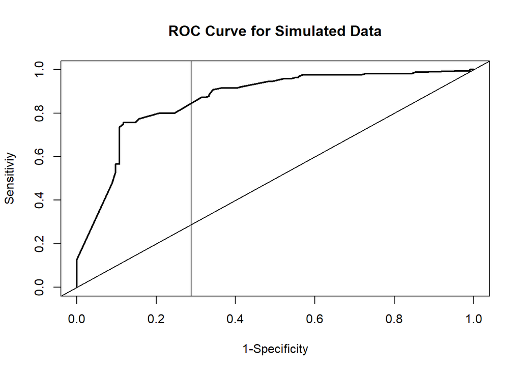

```r
plot_ROC_curve(logistic_intuition$analysis, logistic_intuition$threshold)
```

Recall that the confusion matrix gives us the following information:

| **Prediction\Reference** | **Yes** | **No** |
| --- | --- | --- |
| **Yes** | TP | FP |
| **No** | FN | TN |

Also: * Accuracy = (TP+TN)/(TP + FP + FN + TN) * Sensitivity = TP/(TP + FN) - when it’s actually yes, how often does the model predict yes? True positive, recall * Specificity = TN/(TN + FP) - When it’s actually no, how often does the model predict no? 1-False positive

| **Metric** | **Value** |
| --- | --- |
| Accuracy | 0.8045113 |
| Sensitivity | 0.8823529 |
| Specificity | 0.7560976 |

In this case, we obtained an accuracy of 0.8045113, which is prety good, but can we do better? In the next section we will follow a more data-driven approach to tuning the model.

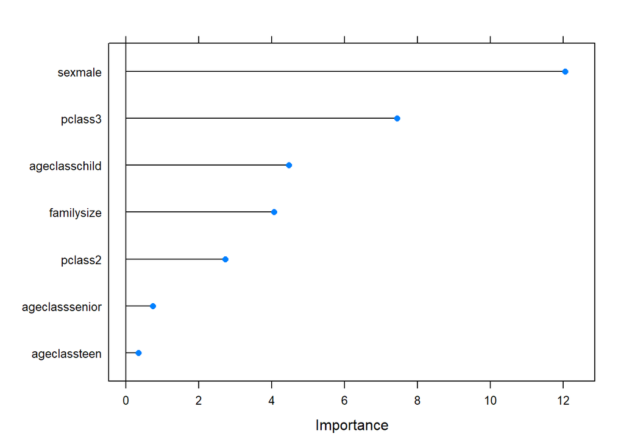

```r
plot(varImp(logistic_intuition$model, scale = FALSE))
```

### Model based on all available variables

We begin by using all available variables in the model:

```r
logistic_full <- evaluate_model(training$original %>% select(-passengerid),
                                     validation$original %>% select(-passengerid))
```

```
##           Reference
## Prediction yes  no
##        yes  85  33
##        no   17 131
##    Accuracy Sensitivity Specificity
##   0.8120301   0.8333333   0.7987805
```

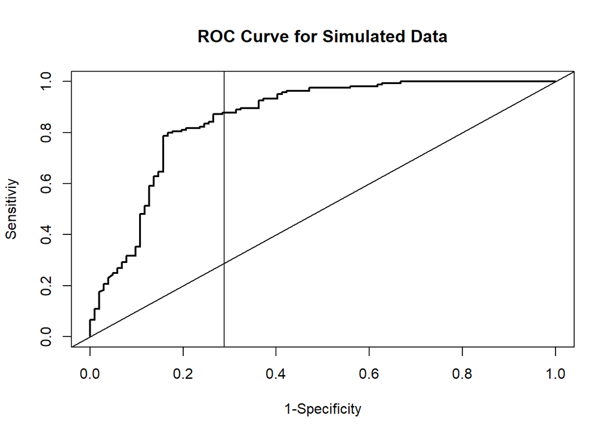

```r
plot_ROC_curve(logistic_full$analysis, logistic_intuition$threshold)
```

We received a number of warnings about rank-deficient prediction. This is due to variables being co-linear. Caret provides information about the relative importance of each variable in the model so we can see which variables play the biggest role.

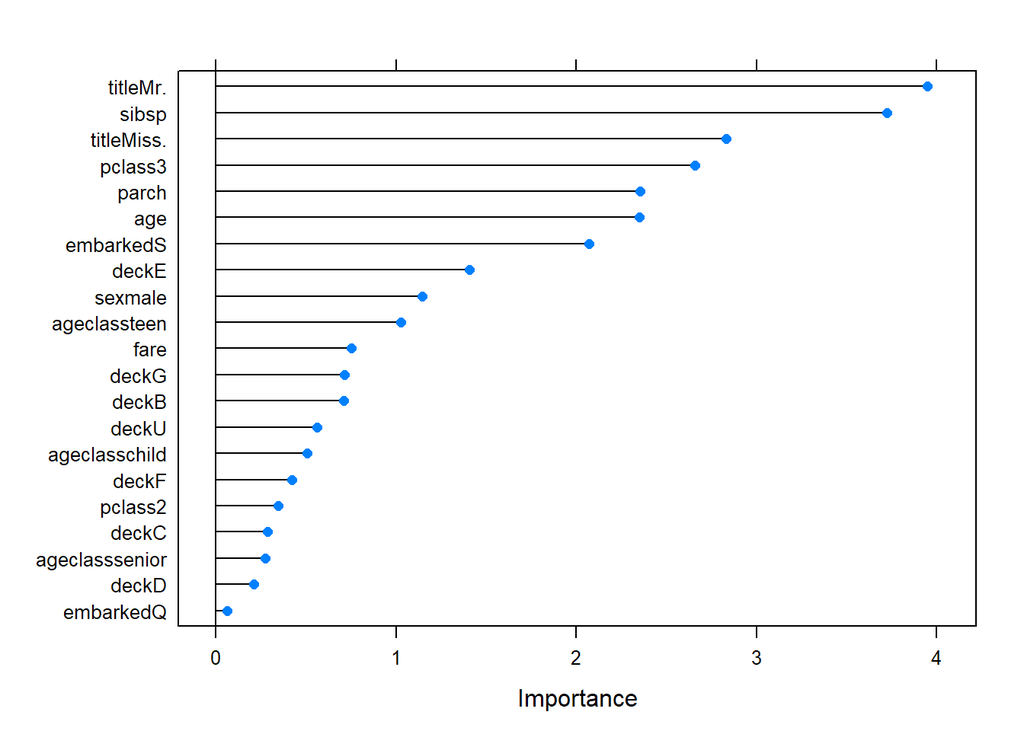

```r
plot(varImp(logistic_full$model, scale = FALSE))
```

## Support Vector Machine

We will carry out a two pass training and tuning process. In the first pass, we use many of the caret defaults, and tune the parameters in the second pass.

```r
svm1 <- train(survived ~ .,
                  data = training$original %>% select(-passengerid),
                  method = 'svmRadial',
                  tuneLength = 9,
                  metric = 'ROC',
                  scale = FALSE,
                  trControl = train_control)
svm1$bestTune
```

```
##        sigma C
## 5 0.05373684 4
```

```r
grid <- expand.grid(sigma = c(0.005, 0.01, 0.02, 0.03),
                    C = c(1.5, 2, 2.5, 3, 3.5, 4, 4.5, 5, 5.5, 6, 7))

svm2 <-  train(survived ~ .,
                  data = training$original %>% select(-passengerid),
                  method = 'svmRadial',
                  tuneGrid = grid,
                  metric = 'ROC',
                  scale = FALSE,
                  trControl = train_control)
svm2$bestTune
```

```
##    sigma C
## 11 0.005 7
```

Let’s check the accuracy of our svm classifier:

```r
svm_pred <- predict(svm2, validation$original %>% select(-passengerid), type = "prob") %>%
  mutate(prediction = ifelse(yes > no, "yes", "no"))

svm_comp <- validation$original %>%
  cbind(prediction = svm_pred$prediction) %>%
  mutate(correct = survived == prediction)
svm_accuracy = svm_comp %>% summarize(accuracy = mean(correct)) %>%
  select(accuracy)
svm_accuracy$accuracy[1]
```

```
## [1] 0.7857143
```

We find that our svm classifier has an accuracy of 78.5714286%

## Neural Network

We now turn our attention to neural networks. We will use a network of nodes with sigmoidal activation functions, commonly referred to as a multilayer perceptron network.

```r
nn_accuracy <- function(model, data){
pred <- predict(model, data)
comp <- cbind(data, prediction = pred) %>%
  mutate(correct = mean(survived == prediction))
accuracy <- comp %>%
  summarize(accuracy = mean(correct))
list("comp" = comp, "accuracy" = accuracy$accuracy[1])
}

nn_train_control <- trainControl(method = "repeatedcv",
                              number = 10,
                              repeats = 5)

n <- names(training$transformed %>% select(-passengerid))
f <- as.formula(paste("survived ~ ", paste(n[!n %in% "survived"], collapse = " + ")))

#nn1 <- caret::train(f,
#             data = training$transformed,
#             method = "mlp",
#             tuneGrid = expand.grid(size = c(5, 10, 15, 20, 25)),
#             trControl = nn_train_control)

#nn_accuracy(nn1, training$transformed)$accuracy
#nn_accuracy(nn1, validation$transformed)$accuracy
```

```r
nn1 <- caret::train(f,
             data = training$transformed,
             method = "mlp",
             tuneGrid = expand.grid(size = c(20)),
             trControl = trainControl(method = "none"))
```

In our initial fit, caret selected 20 nodes in the hidden layer as the optimal network architecture. This gives a training accuracy of 88.3%, and a validation accuracy of 80.83%. There is quite a large gap between these values, indicating that the model may be overfit to the data. Plotting the learning curves can help diagnose this.

```r
nn_lc_trcontrol <- trainControl(method = "none")
nn_learning_curves <-  function(train, test, step, nhidden){
  nrows <- seq(from = 25, to = nrow(train), by = step)
  train_accuracy <- rep(0, length(nrows))
  cv_accuracy <- rep(0, length(nrows))

  n = names(train)
  f = as.formula(paste("survived ~ ", paste(n[!n %in% "survived"], collapse = " + ")))

  for (i in 1:length(nrows)) {
    print(nrows[i])
    nn <-  caret::train(f,
                    data = train %>% head(nrows[i]),
                    method = "mlp",
                    tuneGrid = expand.grid(size = nhidden),
                    trControl = nn_lc_trcontrol)

    train_accuracy[i] <- nn_accuracy(nn, train %>% head(nrows[i]))$accuracy
    cv_accuracy[i] <- nn_accuracy(nn, test)$accuracy
  }

  data.frame(cbind(nrows, train_accuracy, cv_accuracy))
}
plot_learning_curves <- function(plotdf, model){
    ggplot(data = plotdf, aes(x = nrows)) +
      geom_line(aes(y = 1 - train_accuracy, color = "Training"), size = 1) +
      geom_line(aes(y = 1 - cv_accuracy, color = "Validation"), size = 1) +
      xlab("Size of Training Set") +
      ylab("Error (%)") +
      ggtitle(paste("Learning Curves for", model)) +
      theme(legend.title = element_blank())
}
```

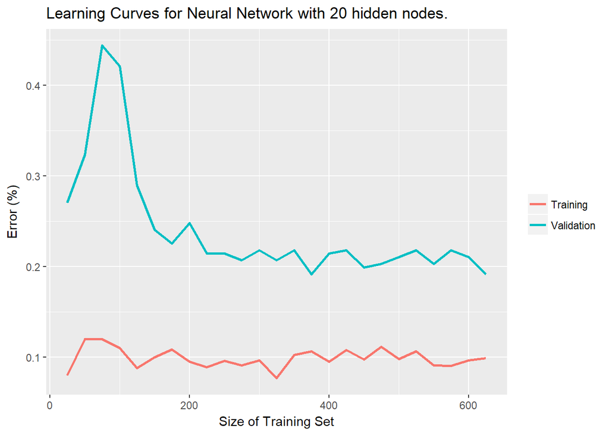

```r
#nn_20_lc <- nn_learning_curves(training$transformed %>% select(-passengerid), validation$transformed %>% select(-passengerid), 25, 20)
#write.csv(nn_20_lc, file = 'output/nn_20_lc.csv')
nn_20_lc <- read_csv('output/nn_20_lc.csv')
plot_learning_curves(nn_20_lc, "Neural Network with 20 hidden nodes.")
```

The learning curves suggest that the model with 20 hidden nodes does indeed overfit the data in the training set. Plotting the learning curves for a network with 15 hidden nodes gives:

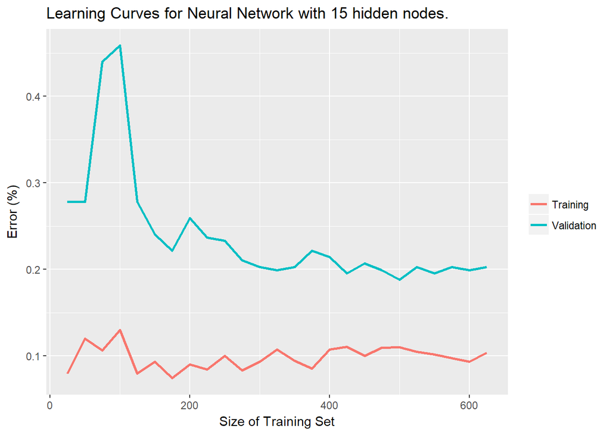

```r
#nn_15_lc <- nn_learning_curves(training$transformed %>% select(-passengerid), validation$transformed %>% select(-passengerid), 25, 15)
#write.csv(nn_15_lc, file = 'output/nn_15_lc.csv')
nn_15_lc <- read_csv('output/nn_15_lc.csv')
plot_learning_curves(nn_15_lc, "Neural Network with 15 hidden nodes.")
```

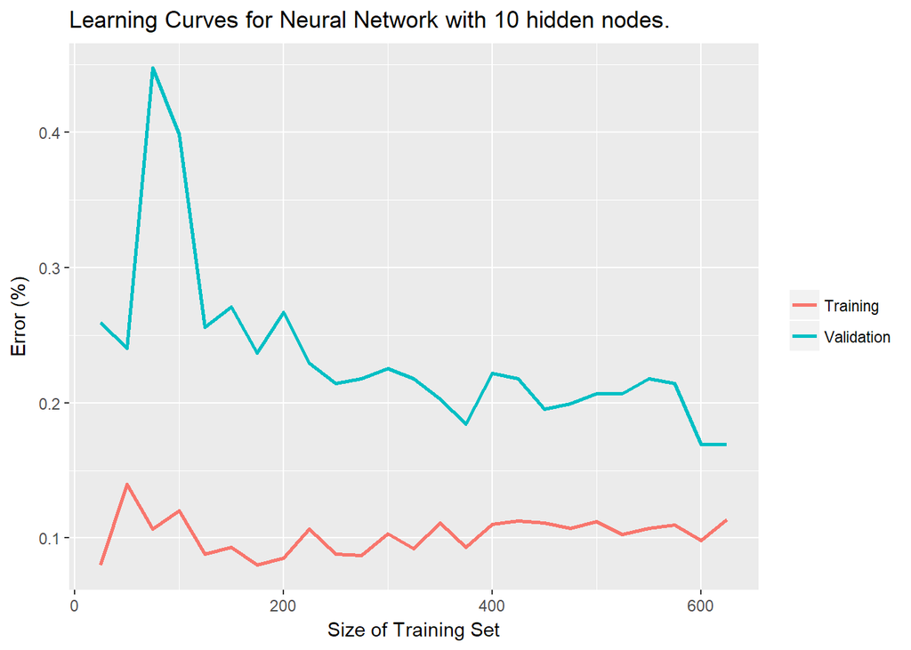

```r
#nn_10_lc <- nn_learning_curves(training$transformed %>% select(-passengerid), validation$transformed %>% select(-passengerid), 25, 10)
#write.csv(nn_10_lc, file = 'output/nn_10_lc.csv')
nn_10_lc <- read_csv('output/nn_10_lc.csv')
plot_learning_curves(nn_10_lc, "Neural Network with 10 hidden nodes.")
```

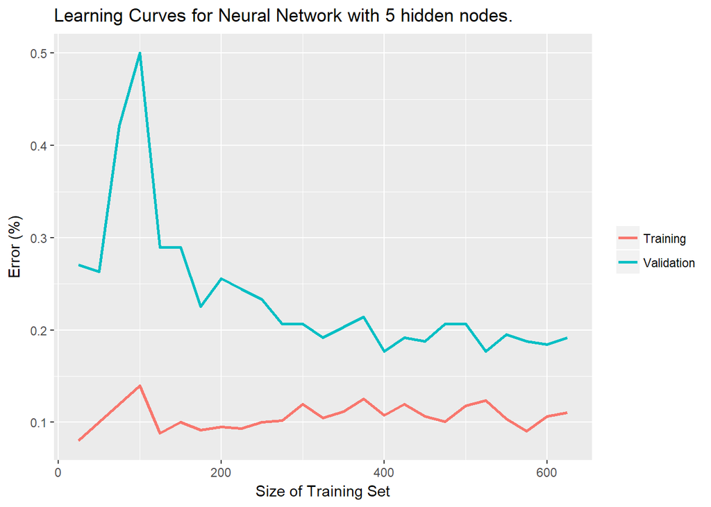

```r
#nn_5_lc <- nn_learning_curves(training$transformed %>% select(-passengerid), validation$transformed %>% select(-passengerid), 25, 5)
#write.csv(nn_5_lc, file = 'output/nn_5_lc.csv')
nn_5_lc <- read_csv('output/nn_5_lc.csv')
plot_learning_curves(nn_5_lc, "Neural Network with 5 hidden nodes.")
```

```r
nn2 <- caret::train(f,
             data = training$transformed,
             method = "mlp",
             tuneGrid = expand.grid(size = c(5)),
             trControl = trainControl(method = "none"))
```

Not sure what’s happening here… There isn’t any difference between the learning curves for models with different numbers of hidden nodes.

Compare a few variants manually:

```r
eval_nn <- function(train, test, nhidden){
n = names(train)
f = as.formula(paste("survived ~ ", paste(n[!n %in% "survived"], collapse = " + ")))

nn_model <-  caret::train(f,
                    data = train,
                    method = "mlp",
                    tuneGrid = expand.grid(size = c(nhidden)),
                    trControl = trainControl(method = "none"))

list("training" = nn_accuracy(nn_model, train)$accuracy,
     "validation" = nn_accuracy(nn_model, test)$accuracy)
}
```

```r
n_hidden <- c(1, 5, 10, 12, 15, 20)
training_accuracy <- rep(0,length(n_hidden))
validation_accuracy <- rep(0,length(n_hidden))
for (i in 1:length(n_hidden)) {
  tmp <- eval_nn(training$transformed %>% select(-passengerid),
                 validation$transformed %>% select(-passengerid), n_hidden[i])
  training_accuracy[i] <- tmp$training
  validation_accuracy[i] <- tmp$validation

  # take model with highest validation accuracy.... use that.
}
nn_results <- data.frame(n_hidden, training_accuracy, validation_accuracy)
nn_results
```

```
##   n_hidden training_accuracy validation_accuracy
## 1        1         0.8653846           0.8082707
## 2        5         0.8830128           0.8007519
## 3       10         0.8814103           0.7894737
## 4       12         0.8942308           0.8120301
## 5       15         0.8814103           0.8157895
## 6       20         0.8814103           0.8233083
```

```r
nn_model <- caret::train(f,
                    data = training$transformed,
                    method = "mlp",
                    tuneGrid = expand.grid(size = c(12)),
                    trControl = trainControl(method = "none"))

nn_accuracy(nn_model,training$transformed)$accuracy
```

```
## [1] 0.8830128
```

```r
nn_accuracy(nn_model,validation$transformed)$accuracy
```

```
## [1] 0.8120301
```

## Random Forest

The last model we will consider is the random forest, using the ranger package’s implementation

```r
ranger_control <- trainControl(method = "repeatedcv",
                              number = 10,
                              repeats = 10,
                              classProbs = TRUE,
                              verboseIter = FALSE)

ranger_model <- train( survived ~ .,
                       data = training$original,
                       method = "ranger",
                       tuneLength = 10,
                       trControl = ranger_control)

ranger_model.pred <- predict(ranger_model, validation$original, type = "prob")
ranger_model.pred$survived <- ifelse(ranger_model.pred[['yes']] > 0.5, 1, 0)
ranger_model.pred$survived <- factor(ranger_model.pred$survived, levels = c(1, 0), labels = c("yes", "no"))

ranger_model.conf <- confusionMatrix(ranger_model.pred$survived, validation$original$survived)
```

| **Metric** | **Value** |
| --- | --- |
| Accuracy | 0.8120301 |
| Sensitivity | 0.7058824 |
| Specificity | 0.8780488 |

## Summary

We have tested 4 models, and collect the accuracy results on the validation datasets here:

| **Model** | **Validation Accuracy (%)** |
| --- | --- |
| Logistic Regression | 81.2 |
| SVM | 78.57% |
| Neural Network | 81.2 |
| Random Forest | 81.2 |

```r
round(logistic_full$conf$overall["Accuracy"]*100, 2)
```

```
## Accuracy
##     81.2
```

```r
round(svm_accuracy$accuracy[1] * 100, 2)
```

```
## [1] 78.57
```

```r
round(nn_accuracy(nn_model,validation$transformed)$accuracy * 100, 2)
```

```
## [1] 81.2
```

```r
round(ranger_model.conf$overall["Accuracy"] * 100, 2)
```

```
## Accuracy
##     81.2
```

# Submission

All of our models have comparable accuracy, with the exception of the SVM model, all are close to 81% accuracy on our validation set. To make the final selection we will apply each model to the provided testing set, and submit the results to Kaggle to see which performs the best.

```r
generate_submission <- function(model, data){

  pred <- predict(model, data)
  submission <- data %>%
    mutate(survived = as.numeric(pred == "yes")) %>%
    select(passengerid, survived) %>%
    rename(PassengerId = passengerid,
           Survived = survived) %>%
    arrange(PassengerId)
  submission
}

sub <- generate_submission(logistic_full$model, test_data)
write.csv(sub, "output/logistic_submission.csv", row.names = FALSE, quote = FALSE)

sub <- generate_submission(svm2, test_data)
write.csv(sub, "output/svm_submission.csv", row.names = FALSE, quote = FALSE)

sub <- generate_submission(ranger_model, test_data)
write.csv(sub, "output/rforest_submission.csv", row.names = FALSE, quote = FALSE)

sub <- generate_submission(nn_model, test_data %>% transform_variables())
write.csv(sub, file = "output/nn_submission.csv", row.names = FALSE, quote = FALSE)
```

Finally, we report the validation accuracy, and the submission accuracy:

[output not shown]